# Tourism - Copy

• The range of age for people that made a purchase is slightly smaller then individuals that didn’t.

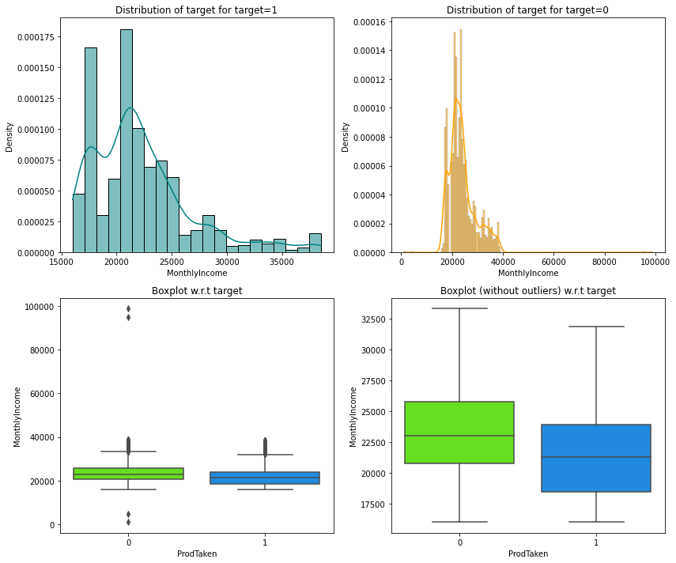

```python
distribution_plot_wrt_target(df, "MonthlyIncome", "ProdTaken")
```

• Individuals that make $20,000 or less a month are those that make purchases and don’t make purchases the most. Customers that don’t make a purchase have a wider range than those that do.

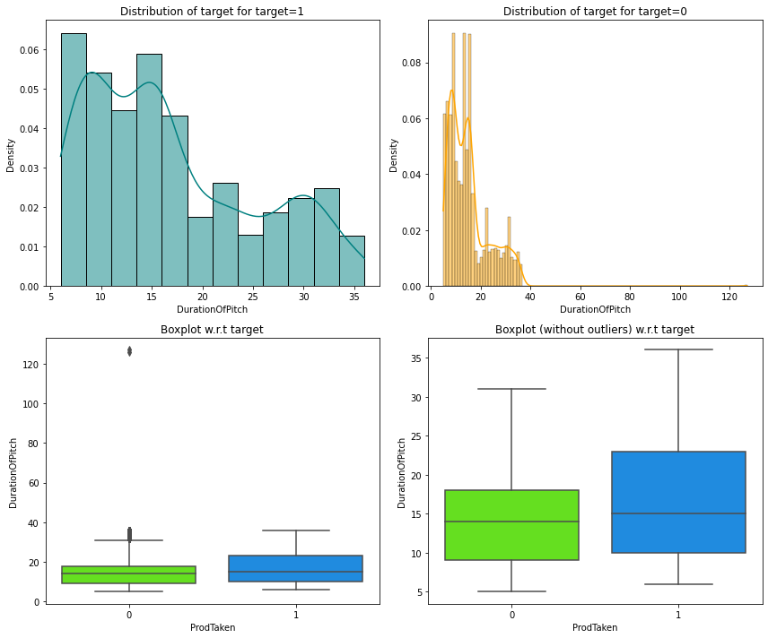

```python
distribution_plot_wrt_target(df, "DurationOfPitch", "ProdTaken")
```

• Looking at the boxplots above we can determine that longer sales pitch durations do result in more sale conversions that shorter ones.

```python
# function to plot stacked bar chart


def stacked_barplot(data, predictor, target):
    """
    Print the category counts and plot a stacked bar chart

    data: dataframe
    predictor: independent variable
    target: target variable
    """
    count = data[predictor].nunique()
    sorter = data[target].value_counts().index[-1]
    tab1 = pd.crosstab(data[predictor], data[target], margins=True).sort_values(
        by=sorter, ascending=False
    )
    print(tab1)
    print("-" * 120)
    tab = pd.crosstab(data[predictor], data[target], normalize="index").sort_values(
        by=sorter, ascending=False
    )
    tab.plot(kind="bar", stacked=True, figsize=(count + 1, 5))
    plt.legend(
        loc="lower left",
        frameon=False,
    )
    plt.legend(loc="upper left", bbox_to_anchor=(1, 1))
    plt.show()
```

```
ProdTaken     0    1   All
CityTier
All        3946  917  4863
1          2655  518  3173
3          1139  353  1492
2           152   46   198
------------------------------------------------------------------------------------------------------------------------
```

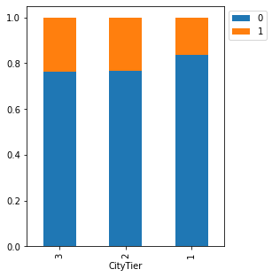

```python
stacked_barplot(df, "CityTier", "ProdTaken")
```

```
PreferredPropertyStar   3.0  3.581765557163531  4.0  5.0   All
CityTier
All                    2974                 26  912  951  4863
1                      1945                 18  573  637  3173
3                       926                  5  285  276  1492
2                       103                  3   54   38   198
------------------------------------------------------------------------------------------------------------------------
```

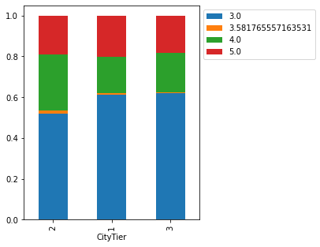

```python
stacked_barplot(df, "CityTier", "PreferredPropertyStar")
```

We see here that roughly 60% of people regardless of City Tier prefer a facility rating of 3.

```
ProdTaken             0    1   All
NumberOfFollowups
All                3946  917  4863
4.0                1683  378  2061
3.0                1214  242  1456
5.0                 573  191   764
6.0                  82   54   136
2.0                 205   24   229
1.0                 152   20   172
3.710668327106683    37    8    45
------------------------------------------------------------------------------------------------------------------------
```

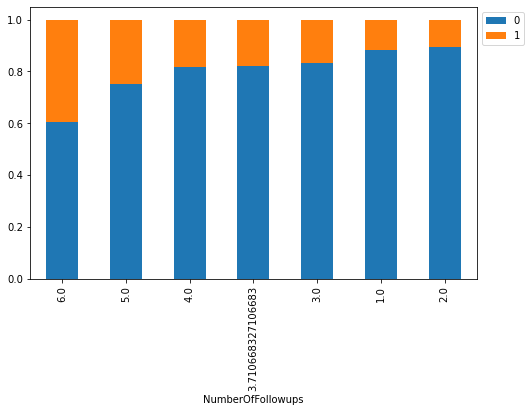

```python
stacked_barplot(df, "NumberOfFollowups", "ProdTaken")
```

• We see here that conversion percentage increases as the number of Follow-ups increases.

```
ProdTaken                 0    1   All
PreferredPropertyStar
All                    3946  917  4863
3.0                    2494  480  2974
5.0                     702  249   951
4.0                     730  182   912
3.581765557163531        20    6    26
------------------------------------------------------------------------------------------------------------------------
```

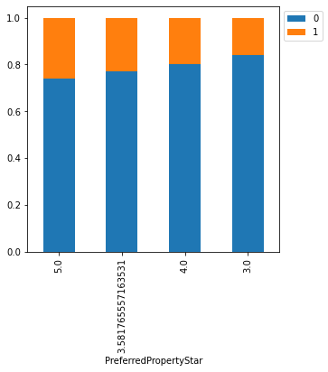

```python
stacked_barplot(df, "PreferredPropertyStar", "ProdTaken")
```

• Conversion percentage based on Property Rating increases as ratings increase.

```
ProdTaken     0    1   All
Passport
All        3946  917  4863
1           928  494  1422
0          3018  423  3441
------------------------------------------------------------------------------------------------------------------------
```

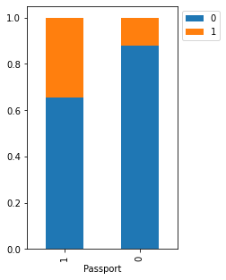

```python
stacked_barplot(df, "Passport", "ProdTaken")
```

• This graph tells up that passport holders have a much higher conversion rate than non-passport holders.

```
PreferredPropertyStar   3.0  3.581765557163531  4.0  5.0   All
Passport
All                    2974                 26  912  951  4863
0                      2090                 19  674  658  3441
1                       884                  7  238  293  1422
------------------------------------------------------------------------------------------------------------------------
```

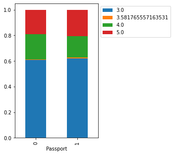

```python
stacked_barplot(df, "Passport", "PreferredPropertyStar")
```

We see here that roughly 60% of people regardless of owning a passport of not prefer a facility rating of 3.

```
ProdTaken     0    1   All
OwnCar
All        3946  917  4863
1          2460  558  3018
0          1486  359  1845
------------------------------------------------------------------------------------------------------------------------
```

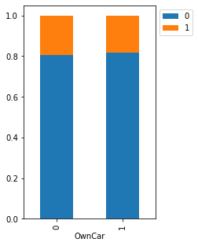

```python
stacked_barplot(df, "OwnCar", "ProdTaken")
```

• Conversion rates between car owners and non -car owners are nearly identical; has not influence on whether a purchase is made. This information may need to be dropped from the data set.

```
ProdTaken     0    1   All
Gender
All        3946  917  4863
Male       2326  575  2901
Female     1620  342  1962
------------------------------------------------------------------------------------------------------------------------
```

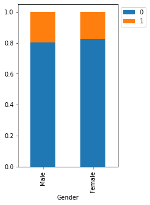

```python
stacked_barplot(df, "Gender", "ProdTaken")
```

• Conversion rate percentage between men and women are close as well. Gender my also be considered for being removed from the data set.

```
PreferredPropertyStar   3.0  3.581765557163531  4.0  5.0   All
Gender
All                    2974                 26  912  951  4863
Male                   1806                 14  527  554  2901
Female                 1168                 12  385  397  1962
------------------------------------------------------------------------------------------------------------------------
```

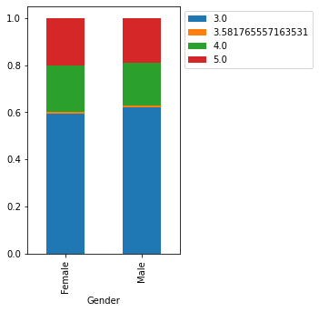

```python
stacked_barplot(df, "Gender", "PreferredPropertyStar")
```

We see here that roughly 60% of people regardless of Gender prefer a facility rating of 3.

```
ProdTaken                  0    1   All
PitchSatisfactionScore
All                     3946  917  4863
3                       1152  314  1466
5                        757  210   967
4                        748  162   910
1                        794  143   937
2                        495   88   583
------------------------------------------------------------------------------------------------------------------------
```

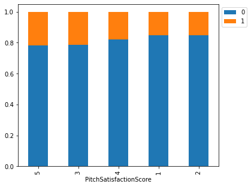

```python
stacked_barplot(df, "PitchSatisfactionScore", "ProdTaken")
```

```
ProdTaken                  0    1   All
NumberOfPersonVisiting
All                     3946  917  4863
3                       1935  459  2394
2                       1136  265  1401
4                        833  193  1026
1                         39    0    39
5                          3    0     3
------------------------------------------------------------------------------------------------------------------------
```

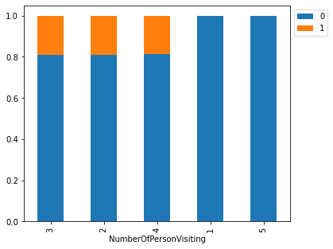

```python
stacked_barplot(df, "NumberOfPersonVisiting", "ProdTaken")
```

• Parties of two, three, or four people have a conversion rate of about 20%. Oddly, parties of one and five show 0%. The marketing team needs to take a strong look into this.

```
ProdTaken                    0    1   All
NumberOfChildrenVisiting
All                       3946  917  4863
1.0                       1678  391  2069
2.0                       1080  253  1333
0.0                        870  200  1070
3.0                        259   66   325
1.1903272878882636          59    7    66
------------------------------------------------------------------------------------------------------------------------
```

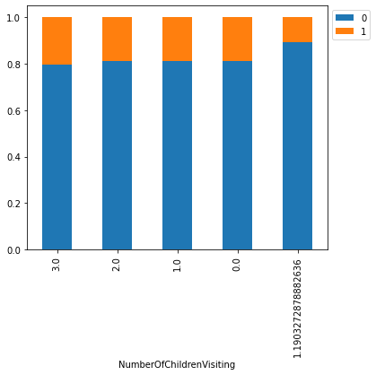

```python
stacked_barplot(df, "NumberOfChildrenVisiting", "ProdTaken")
```

• Number of children doesn’t seem to have too much of an impact on conversion rates. Looks even across the board with some change on the low end.

```
PreferredPropertyStar      3.0  3.581765557163531  4.0  5.0   All
NumberOfChildrenVisiting
All                       2974                 26  912  951  4863
2.0                        800                 10  254  269  1333
1.0                       1291                  8  376  394  2069
3.0                        176                  7   68   74   325
0.0                        676                  1  196  197  1070
1.1903272878882636          31                  0   18   17    66
------------------------------------------------------------------------------------------------------------------------
```

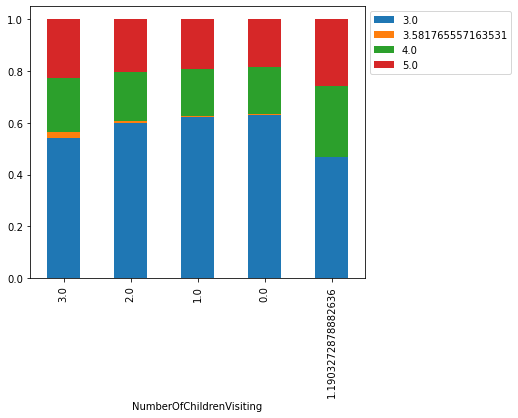

```python
stacked_barplot(df, "NumberOfChildrenVisiting", "PreferredPropertyStar")
```

We see here that roughly 60% of people regardless of the numner of children visiing prefer a facility rating of 3

```
ProdTaken         0    1   All
MaritalStatus
All            3946  917  4863
Married        1999  326  2325
Single          610  302   912
Unmarried       516  166   682
Divorced        821  123   944
------------------------------------------------------------------------------------------------------------------------
```

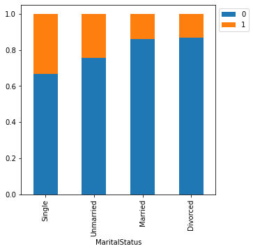

```python
stacked_barplot(df, "MaritalStatus", "ProdTaken")
```

• Singles convert higher than individuals that come with a companion or have been marred previously. The guests may be out to meet a partner; versus the other categories.

```
PreferredPropertyStar   3.0  3.581765557163531  4.0  5.0   All
MaritalStatus
All                    2974                 26  912  951  4863
Married                1401                 14  438  472  2325
Divorced                577                  6  180  181   944
Single                  563                  6  182  161   912
Unmarried               433                  0  112  137   682
------------------------------------------------------------------------------------------------------------------------
```

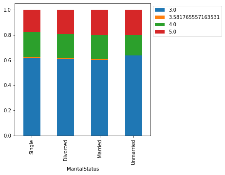

```python
stacked_barplot(df, "MaritalStatus", "PreferredPropertyStar")
```

We see here that roughly 60% of people regardless of Marital Status prefer a facility rating of 3

```
ProdTaken           0    1   All
TypeofContact
All              3946  917  4863
Self Enquiry     2837  607  3444
Company Invited  1109  310  1419
------------------------------------------------------------------------------------------------------------------------
```

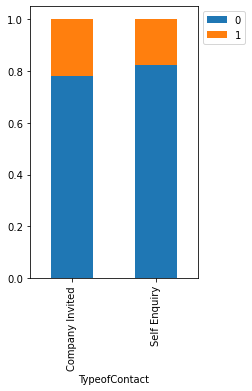

```python
stacked_barplot(df, "TypeofContact", "ProdTaken")
```

```
ProdTaken          0    1   All
ProductPitched
All             3946  917  4863
Basic           1283  549  1832
Deluxe          1513  204  1717
Standard         618  124   742
King             210   20   230
Super Deluxe     322   20   342
------------------------------------------------------------------------------------------------------------------------
```

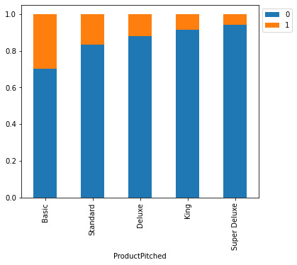

```python
stacked_barplot(df, "ProductPitched", "ProdTaken")
```

• The basic package converts at a higher rate than other packages. This too may be cost related.

```
ProdTaken          0    1   All
Occupation
All             3946  917  4863
Salaried        1950  413  2363
Small Business  1682  382  2064
Large Business   314  120   434
Free Lancer        0    2     2
------------------------------------------------------------------------------------------------------------------------
```

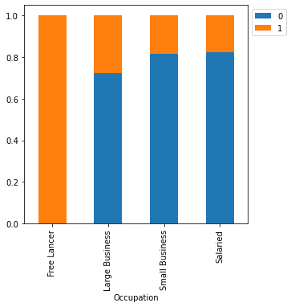

```python
stacked_barplot(df, "Occupation", "ProdTaken")
```

• Free Lancers and Large Business Owners needed more advertising aimed at them; there's seemingly lots of sales being missed here.

```
PreferredPropertyStar   3.0  3.581765557163531  4.0  5.0   All
Occupation
All                    2974                 26  912  951  4863
Salaried               1499                 16  400  448  2363
Small Business         1215                  8  422  419  2064
Large Business          258                  2   90   84   434
Free Lancer               2                  0    0    0     2
------------------------------------------------------------------------------------------------------------------------
```

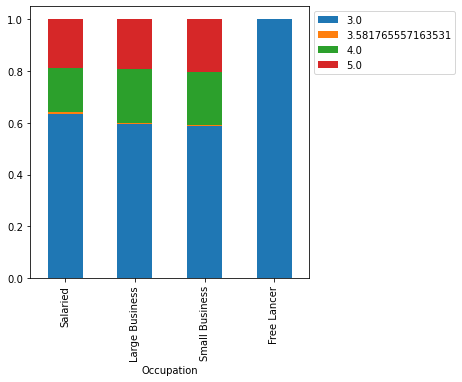

```python
stacked_barplot(df, "Occupation", "PreferredPropertyStar")
```

```
ProdTaken          0    1   All
Designation
All             3946  917  4863
Executive       1283  549  1832
Manager         1513  204  1717
Senior Manager   618  124   742
AVP              322   20   342
VP               210   20   230
------------------------------------------------------------------------------------------------------------------------
```

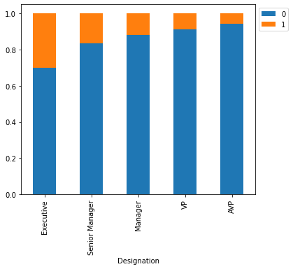

```python
stacked_barplot(df, "Designation", "ProdTaken")
```

```
o   There is a significant difference in the conversion rate between this group and the others.
```

```
o   The marketing team needs to look at making packages better targeted at this group or focusing efforts elsewhere.
```

```
PreferredPropertyStar   3.0  3.581765557163531  4.0  5.0   All
Designation
All                    2974                 26  912  951  4863
VP                      137                 23   41   29   230
Executive              1111                  1  368  352  1832
Manager                1078                  1  311  327  1717
Senior Manager          436                  1  130  175   742
AVP                     212                  0   62   68   342
------------------------------------------------------------------------------------------------------------------------
```

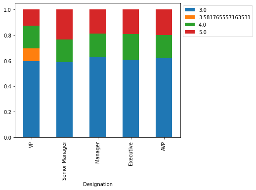

```python
stacked_barplot(df, "Designation", "PreferredPropertyStar")
```

It is safe to say that most customers will opt for a facility rating of 3 based on related graphs above.

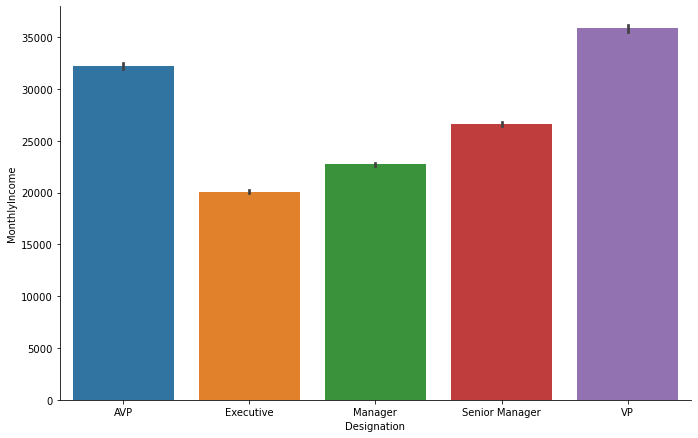

```python
sns.catplot(x="Designation", y="MonthlyIncome", data=df, kind='bar', height=6, aspect=1.6, estimator=np.mean);
```

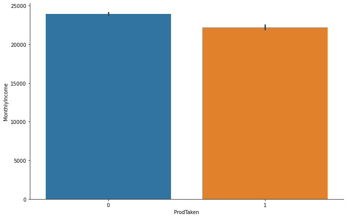

```python
sns.catplot(x="ProdTaken", y="MonthlyIncome", data=df, kind='bar', height=6, aspect=1.6, estimator=np.mean);
```

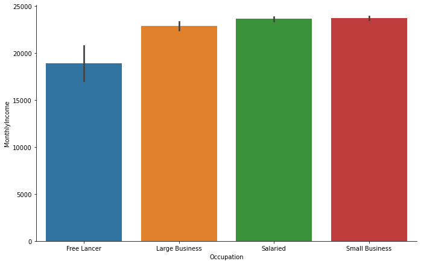

```python
sns.catplot(x="Occupation", y="MonthlyIncome", data=df, kind='bar', height=6, aspect=1.6, estimator=np.mean);
```

## Customer Profile

• 60% of customers purchase at a facility rating of 3 regardless of many variables and/or differences.

[output not shown]

• Passport owners have a higher conversion rate than non-holders.

• Vehicle owner ship plays no role in the decision to purchase

• Parties of people between 2 and 4 have a higher conversion rate than parties of 1 or 5.

```
o   Peoples in party of 3 making most purchases.
```

• Salaried individuals and small business owners make significantly more purchases than freelancers and large business owners.

• Single and Unmarred(dating) customers convert at a higher rate than Married or Divorced individuals.

[output not shown]

• The Basic package converts higher than all others, which is also the one that is pitched the most.

Customer Likely to Purchase:

• Individuals that come in parties of 3

• Salaried Customers and Small Business Owners

```
o   These customers also have the highest monthly incomes: important to note.
```

• Unmarried and Single individuals

• Customers seeking to purchase the basic package.

# Model Building Steps

1. Data preparation
2. Partition the data into train and test set.
3. Build model on the train data.
4. Tune the model if required.
5. Test the data on test set.

# Splitting Data

```python
#Dropping variables not needed.
df.drop(['PitchSatisfactionScore', 'ProductPitched','NumberOfFollowups', 'DurationOfPitch'],axis=1,inplace=True)
```

```python
X = df.drop(['ProdTaken'],axis=1)
X = pd.get_dummies(X,drop_first=True)
y = df['ProdTaken']
```

```python
X.head()
```

|  | Age | CityTier | NumberOfPersonVisiting | PreferredPropertyStar | NumberOfTrips | Passport | OwnCar | NumberOfChildrenVisiting | MonthlyIncome | TypeofContact_Self Enquiry | ... | Occupation_Salaried | Occupation_Small Business | Gender_Male | MaritalStatus_Married | MaritalStatus_Single | MaritalStatus_Unmarried | Designation_Executive | Designation_Manager | Designation_Senior Manager | Designation_VP |
| --- | --- | --- | --- | --- | --- | --- | --- | --- | --- | --- | --- | --- | --- | --- | --- | --- | --- | --- | --- | --- | --- |
| 0 | 41.000000 | 3 | 3 | 3.0 | 1.0 | 1 | 1 | 0.0 | 20993.0 | 1 | ... | 1 | 0 | 0 | 0 | 1 | 0 | 0 | 1 | 0 | 0 |
| 1 | 49.000000 | 1 | 3 | 4.0 | 2.0 | 0 | 1 | 2.0 | 20130.0 | 0 | ... | 1 | 0 | 1 | 0 | 0 | 0 | 0 | 1 | 0 | 0 |
| 2 | 37.000000 | 1 | 3 | 3.0 | 7.0 | 1 | 0 | 0.0 | 17090.0 | 1 | ... | 0 | 0 | 1 | 0 | 1 | 0 | 1 | 0 | 0 | 0 |
| 3 | 33.000000 | 1 | 2 | 3.0 | 2.0 | 1 | 1 | 1.0 | 17909.0 | 0 | ... | 1 | 0 | 0 | 0 | 0 | 0 | 1 | 0 | 0 | 0 |
| 4 | 37.662929 | 1 | 2 | 4.0 | 1.0 | 0 | 1 | 0.0 | 18468.0 | 1 | ... | 0 | 1 | 1 | 0 | 0 | 0 | 1 | 0 | 0 | 0 |

5 rows × 21 columns

```python
# Splitting data into training and test set:
X_train, X_test, y_train, y_test =train_test_split(X, y, test_size=0.3, random_state=1,stratify=y)
print(X_train.shape, X_test.shape)
```

```
(3404, 21) (1459, 21)
```

```python
y.value_counts(1)
```

```
0    0.811433
1    0.188567
Name: ProdTaken, dtype: float64
```

```python
y_test.value_counts(1)
```

```
0    0.811515
1    0.188485
Name: ProdTaken, dtype: float64
```

# Model evaluation criterion

Model can make wrong predictions as:

```
1. Predicting a customer will make a purchase and they don't.

2. Predicting a customer will not make a purchase and they do.
```

# Which case is more important?

# How to reduce this loss i.e need to reduce False Negatives?

#### Company wants Recall to be maximized, greater the Recall higher the chances of minimizing false negatives. Hence, the focus should be on increasing Recall or minimizing the false negatives or in other words identifying the true positives(i.e. Class 1) so that the business can develope accurate marketing tools to grow sales.

# Functions to measure important metrics:

```python
# defining a function to compute different metrics to check performance of a classification model built using sklearn
def model_performance_classification_sklearn(model, predictors, target):
    """
    Function to compute different metrics to check classification model performance

    model: classifier
    predictors: independent variables
    target: dependent variable
    """

    # predicting using the independent variables
    pred = model.predict(predictors)

    acc = accuracy_score(target, pred)  # to compute Accuracy
    recall = recall_score(target, pred)  # to compute Recall
    precision = precision_score(target, pred)  # to compute Precision
    f1 = f1_score(target, pred)  # to compute F1-score

    # creating a dataframe of metrics
    df_perf = pd.DataFrame(
        {
            "Accuracy": acc,
            "Recall": recall,
            "Precision": precision,
            "F1": f1,
        },
        index=[0],
    )

    return df_perf
```

```python
def confusion_matrix_sklearn(model, predictors, target):
    """
    To plot the confusion_matrix with percentages

    model: classifier
    predictors: independent variables
    target: dependent variable
    """
    y_pred = model.predict(predictors)
    cm = confusion_matrix(target, y_pred)
    labels = np.asarray(
        [
            ["{0:0.0f}".format(item) + "\n{0:.2%}".format(item / cm.flatten().sum())]
            for item in cm.flatten()
        ]
    ).reshape(2, 2)

    plt.figure(figsize=(6, 4))
    sns.heatmap(cm, annot=labels, fmt="")
    plt.ylabel("True label")
    plt.xlabel("Predicted label")
```

```python
## Function to create confusion matrix
def make_confusion_matrix(model,y_actual,labels=[1, 0]):
    '''
    model : classifier to predict values of X
    y_actual : ground truth

    '''
    y_predict = model.predict(X_test)
    cm=metrics.confusion_matrix( y_actual, y_predict, labels=[0, 1])
    df_cm = pd.DataFrame(cm, index = [i for i in ["Actual - No","Actual - Yes"]],
                  columns = [i for i in ['Predicted - No','Predicted - Yes']])
    group_counts = ["{0:0.0f}".format(value) for value in
                cm.flatten()]
    group_percentages = ["{0:.2%}".format(value) for value in
                         cm.flatten()/np.sum(cm)]
    labels = [f"{v1}\n{v2}" for v1, v2 in
              zip(group_counts,group_percentages)]
    labels = np.asarray(labels).reshape(2,2)
    plt.figure(figsize = (10,7))
    sns.heatmap(df_cm, annot=labels,fmt='')
    plt.ylabel('True label')
    plt.xlabel('Predicted label')
```

```python
##  Function to calculate different metric scores of the model - Accuracy, Recall and Precision
def get_metrics_score(model,flag=True):
    '''
    model : classifier to predict values of X

    '''
    # defining an empty list to store train and test results
    score_list=[]

    pred_train = model.predict(X_train)
    pred_test = model.predict(X_test)

    train_acc = model.score(X_train,y_train)
    test_acc = model.score(X_test,y_test)

    train_recall = metrics.recall_score(y_train,pred_train)
    test_recall = metrics.recall_score(y_test,pred_test)

    train_precision = metrics.precision_score(y_train,pred_train)
    test_precision = metrics.precision_score(y_test,pred_test)


    score_list.extend((train_acc,test_acc,train_recall,test_recall,train_precision,test_precision))

    # If the flag is set to True then only the following print statements will be dispayed. The default value is set to True.
    if flag == True:
        print("Accuracy on training set : ",model.score(X_train,y_train))
        print("Accuracy on test set : ",model.score(X_test,y_test))
        print("Recall on training set : ",metrics.recall_score(y_train,pred_train))
        print("Recall on test set : ",metrics.recall_score(y_test,pred_test))
        print("Precision on training set : ",metrics.precision_score(y_train,pred_train))
        print("Precision on test set : ",metrics.precision_score(y_test,pred_test))

    return score_list # returning the list with train and test scores
```

# Build Decision Tree Model

```python
dtree = DecisionTreeClassifier(criterion='gini',class_weight={0:0.17,1:0.83},random_state=1)
```

```python
dtree.fit(X_train, y_train)
```

```
DecisionTreeClassifier(class_weight={0: 0.17, 1: 0.83}, random_state=1)
```

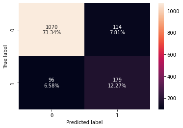

```python
confusion_matrix_sklearn(dtree, X_test, y_test)
```

## Confustion Matrix

```
•   Customer was predicted to purchase and did: True Positive (observed=1, predicted=1)
•   Customer was predicted to purchase and did not: False Positive (observed=0, predicted=1)
•   Customer was predicted not to purchase and did not: True Negative (observed=0, predicted=0)
•   Customer was predicted not to purchase but did: False Negative (observed=1, predicted=0)
```

```python
dtree_model_train_perf=model_performance_classification_sklearn(dtree, X_train, y_train)
print("Training performance \n",dtree_model_train_perf)
```

```
Training performance
    Accuracy  Recall  Precision   F1
0       1.0     1.0        1.0  1.0
```

```python
dtree_model_test_perf=model_performance_classification_sklearn(dtree, X_test, y_test)
print("Testing performance \n",dtree_model_test_perf)
```

```
Testing performance
    Accuracy    Recall  Precision        F1
0  0.856066  0.650909   0.610922  0.630282
```

• The Decision Tree did well on the training data but not on the test data. Adjusts will be made to improve fitting. Recall is the main focus here.

## Bagging Classifier

```python
bagging = BaggingClassifier(random_state=1)
bagging.fit(X_train,y_train)
```

```
BaggingClassifier(random_state=1)
```

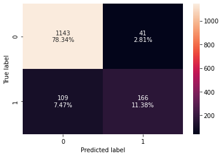

```python
confusion_matrix_sklearn(bagging, X_test, y_test)
```

```python
bagging_model_train_perf=model_performance_classification_sklearn(bagging, X_train, y_train)
print("Training performance \n",bagging_model_train_perf)
```

```
Training performance
    Accuracy    Recall  Precision        F1
0  0.991774  0.961059   0.995161  0.977813
```

```python
bagging_model_test_perf=model_performance_classification_sklearn(bagging, X_test, y_test)
print("Testing performance \n",bagging_model_test_perf)
```

```
Testing performance
    Accuracy    Recall  Precision        F1
0   0.89719  0.603636   0.801932  0.688797
```

• The Bagging Classifier is overfitting the training data and performing poorly on the test data. We will continue to work towards a better solution.

### Weighted Bagging Classifier

```python
bagging_wt = BaggingClassifier(base_estimator=DecisionTreeClassifier(criterion='gini',class_weight={0:0.17,1:0.83},random_state=1),random_state=1)
bagging_wt.fit(X_train,y_train)
```

```
BaggingClassifier(base_estimator=DecisionTreeClassifier(class_weight={0: 0.17,
                                                                      1: 0.83},
                                                        random_state=1),
                  random_state=1)
```

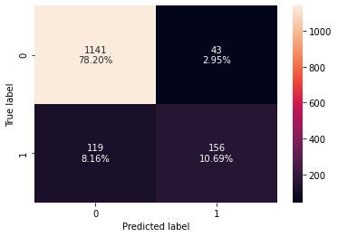

```python
confusion_matrix_sklearn(bagging_wt,X_test,y_test)
```

```python
bagging_wt_model_train_perf=model_performance_classification_sklearn(bagging_wt,X_train,y_train)
print("Training performance \n",bagging_wt_model_train_perf)
```

```
Training performance
    Accuracy    Recall  Precision        F1
0  0.992068  0.959502   0.998379  0.978554
```

```python
bagging_wt_model_test_perf=model_performance_classification_sklearn(bagging_wt, X_test, y_test)
print("Testing performance \n",bagging_wt_model_test_perf)
```

```
Testing performance
    Accuracy    Recall  Precision        F1
0  0.888965  0.567273    0.78392  0.658228
```

Bagging classifier with a weighted decision tree is giving very good accuracy and prediction but is not able to generalize well on test data in terms of recall.

## Random Forest

```python
rf = RandomForestClassifier(random_state=1)
rf.fit(X_train,y_train)
```

```
RandomForestClassifier(random_state=1)
```

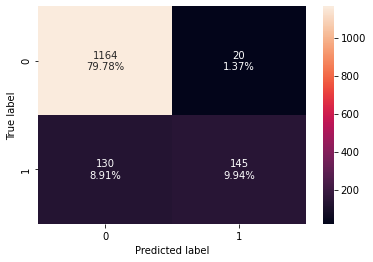

```python
confusion_matrix_sklearn(rf,X_test,y_test)
```

```python
rf_model_train_perf=model_performance_classification_sklearn(rf,X_train,y_train)
print("Training performance \n",rf_model_train_perf)
```

```
Training performance
    Accuracy  Recall  Precision   F1
0       1.0     1.0        1.0  1.0
```

```python
rf_model_test_perf=model_performance_classification_sklearn(rf,X_test,y_test)
print("Testing performance \n",rf_model_test_perf)
```

```
Testing performance
    Accuracy    Recall  Precision        F1
0   0.89719  0.527273   0.878788  0.659091
```

• The same issue persists with recall in regard to the test data.

## Weighted Random Forest Classifier

```python
rf_wt = RandomForestClassifier(class_weight={0:0.17,1:0.83}, random_state=1)
rf_wt.fit(X_train,y_train)
```

```
RandomForestClassifier(class_weight={0: 0.17, 1: 0.83}, random_state=1)
```

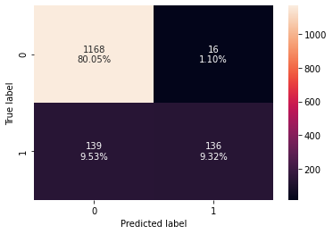

```python
confusion_matrix_sklearn(rf_wt, X_test,y_test)
```

```python
rf_wt_model_train_perf=model_performance_classification_sklearn(rf_wt, X_train,y_train)
print("Training performance \n",rf_wt_model_train_perf)
```

```
Training performance
    Accuracy  Recall  Precision   F1
0       1.0     1.0        1.0  1.0
```

```python
rf_wt_model_test_perf=model_performance_classification_sklearn(rf_wt, X_test,y_test)
print("Testing performance \n",rf_wt_model_test_perf)
```

```
Testing performance
    Accuracy    Recall  Precision        F1
0  0.893763  0.494545   0.894737  0.637002
```

• The same issue persists with recall in regard to the test data.

# Using GridSearch for Hyperparameter tuning model

## Decision Tree Estimator

```python
# Choose the type of classifier.
dtree_estimator = DecisionTreeClassifier(class_weight={0:0.17,1:0.83},random_state=1)

# Grid of parameters to choose from
parameters = {'max_depth': np.arange(2,30),
              'min_samples_leaf': [1, 2, 5, 7, 10],
              'max_leaf_nodes' : [2, 3, 5, 10,15],
              'min_impurity_decrease': [0.0001,0.001,0.01,0.1]
             }

# Type of scoring used to compare parameter combinations
scorer = metrics.make_scorer(metrics.recall_score)

# Run the grid search
grid_obj = GridSearchCV(dtree_estimator, parameters, scoring=scorer)
grid_obj = grid_obj.fit(X_train, y_train)

# Set the clf to the best combination of parameters
dtree_estimator = grid_obj.best_estimator_

# Fit the best algorithm to the data.
dtree_estimator.fit(X_train, y_train)
```

```
DecisionTreeClassifier(class_weight={0: 0.17, 1: 0.83}, max_depth=2,
                       max_leaf_nodes=2, min_impurity_decrease=0.1,
                       random_state=1)
```

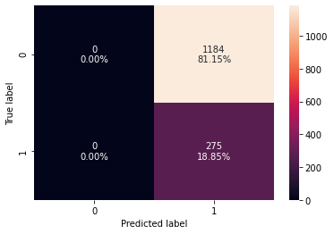

```python
confusion_matrix_sklearn(dtree_estimator, X_test,y_test)
```

```python
dtree_estimator_model_train_perf=model_performance_classification_sklearn(dtree_estimator, X_train,y_train)
print("Training performance \n",dtree_estimator_model_train_perf)
```

```
Training performance
    Accuracy  Recall  Precision       F1
0  0.188602     1.0   0.188602  0.31735
```

```python
dtree_estimator_model_test_perf=model_performance_classification_sklearn(dtree_estimator, X_test, y_test)
print("Testing performance \n",dtree_estimator_model_test_perf)
```

```
Testing performance
    Accuracy  Recall  Precision        F1
0  0.188485     1.0   0.188485  0.317186
```

• The tuned tree does well as far as recall on the training and test data, but underfits in other areas.

## Bagging Estimator

```python
# grid search for bagging classifier
cl1 = DecisionTreeClassifier(class_weight={0:0.13,1:0.87},random_state=1)
param_grid = {'base_estimator':[cl1],
              'n_estimators':[5,7,15,51,101],
              'max_features': [0.7,0.8,0.9,1]
             }

grid = GridSearchCV(BaggingClassifier(random_state=1,bootstrap=True), param_grid=param_grid, scoring = 'recall', cv = 5)
grid.fit(X_train, y_train)
```

```
GridSearchCV(cv=5, estimator=BaggingClassifier(random_state=1),
             param_grid={'base_estimator': [DecisionTreeClassifier(class_weight={0: 0.13,
                                                                                 1: 0.87},
                                                                   random_state=1)],
                         'max_features': [0.7, 0.8, 0.9, 1],
                         'n_estimators': [5, 7, 15, 51, 101]},
             scoring='recall')
```

```python
## getting the best estimator
bagging_estimator  = grid.best_estimator_
bagging_estimator.fit(X_train,y_train)
```

```
BaggingClassifier(base_estimator=DecisionTreeClassifier(class_weight={0: 0.13,
                                                                      1: 0.87},
                                                        random_state=1),
                  max_features=1, n_estimators=7, random_state=1)
```

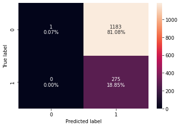

```python
confusion_matrix_sklearn(bagging_estimator, X_test,y_test)
```

```python
bagging_estimator_model_train_perf=model_performance_classification_sklearn(bagging_estimator, X_train,y_train)
print("Training performance \n",bagging_estimator_model_train_perf)
```

```
Training performance
    Accuracy  Recall  Precision        F1
0  0.189483     1.0   0.188768  0.317586
```

```python
bagging_estimator_model_test_perf=model_performance_classification_sklearn(bagging_estimator, X_test, y_test)
print("Testing performance \n",bagging_estimator_model_test_perf)
```

```
Testing performance
    Accuracy  Recall  Precision        F1
0  0.189171     1.0   0.188615  0.317369
```

• Same issue persists as the previous results.

## Random Forest Estimator

```python
# Choose the type of classifier.
rf_estimator = RandomForestClassifier(random_state=1)

# Grid of parameters to choose from
parameters = {
        "n_estimators": [110,251,501],
        "min_samples_leaf": np.arange(1, 6,1),
        "max_features": [0.7,0.9,'log2','auto'],
        "max_samples": [0.7,0.9,None],
}

# Run the grid search
grid_obj = GridSearchCV(rf_estimator, parameters, scoring='recall',cv=5)
grid_obj = grid_obj.fit(X_train, y_train)

# Set the clf to the best combination of parameters
rf_estimator = grid_obj.best_estimator_

# Fit the best algorithm to the data.
rf_estimator.fit(X_train, y_train)
```

```
RandomForestClassifier(max_features=0.7, n_estimators=251, random_state=1)
```

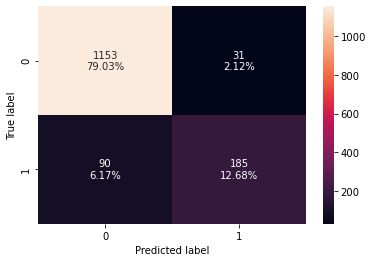

```python
confusion_matrix_sklearn(rf_estimator, X_test,y_test)
```

```python
rf_estimator_model_train_perf=model_performance_classification_sklearn(rf_estimator, X_train,y_train)
print("Training performance \n",rf_estimator_model_train_perf)
```

```
Training performance
    Accuracy  Recall  Precision   F1
0       1.0     1.0        1.0  1.0
```

```python
rf_estimator_model_test_perf=model_performance_classification_sklearn(rf_estimator, X_test, y_test)
print("Testing performance \n",rf_estimator_model_test_perf)
```

```
Testing performance
    Accuracy    Recall  Precision        F1
0  0.917066  0.672727   0.856481  0.753564
```

• Random Forest tunning has showed improvement, but we will continue to push for better results.

## Comparing all the models

```python
# training performance comparison

models_train_comp_df = pd.concat(
    [dtree_model_train_perf.T,bagging_model_train_perf.T, bagging_wt_model_train_perf.T,rf_model_train_perf.T,
    rf_wt_model_train_perf.T,dtree_estimator_model_train_perf.T, bagging_estimator_model_train_perf.T,
     rf_estimator_model_train_perf.T],
    axis=1,
)
models_train_comp_df.columns = [
    "Decision Tree",
    "Bagging Classifier",
    "Weighted Bagging Classifier",
    "Random Forest Classifier",
    "Weighted Random Forest Classifier",
    "Decision Tree Estimator",
    "Bagging Estimator",
    "Random Forest Estimator"]
print("Training performance comparison:")
models_train_comp_df
```

```
Training performance comparison:
```

|  | Decision Tree | Bagging Classifier | Weighted Bagging Classifier | Random Forest Classifier | Weighted Random Forest Classifier | Decision Tree Estimator | Bagging Estimator | Random Forest Estimator |
| --- | --- | --- | --- | --- | --- | --- | --- | --- |
| Accuracy | 1.0 | 0.991774 | 0.992068 | 1.0 | 1.0 | 0.188602 | 0.189483 | 1.0 |
| Recall | 1.0 | 0.961059 | 0.959502 | 1.0 | 1.0 | 1.000000 | 1.000000 | 1.0 |
| Precision | 1.0 | 0.995161 | 0.998379 | 1.0 | 1.0 | 0.188602 | 0.188768 | 1.0 |
| F1 | 1.0 | 0.977813 | 0.978554 | 1.0 | 1.0 | 0.317350 | 0.317586 | 1.0 |

```python
# training performance comparison

models_test_comp_df = pd.concat(
    [dtree_model_test_perf.T,bagging_model_test_perf.T, bagging_wt_model_test_perf.T,rf_model_test_perf.T,
    rf_wt_model_test_perf.T,dtree_estimator_model_test_perf.T, bagging_estimator_model_test_perf.T,
     rf_estimator_model_test_perf.T],
    axis=1,
)
models_test_comp_df.columns = [
    "Decision Tree",
    "Bagging Classifier",
    "Weighted Bagging Classifier",
    "Random Forest Classifier",
    "Weighted Random Forest Classifier",
    "Decision Tree Estimator",
    "Bagging Estimator",
    "Random Forest Estimator"]
print("Testing performance comparison:")
models_test_comp_df
```

```
Testing performance comparison:
```

|  | Decision Tree | Bagging Classifier | Weighted Bagging Classifier | Random Forest Classifier | Weighted Random Forest Classifier | Decision Tree Estimator | Bagging Estimator | Random Forest Estimator |
| --- | --- | --- | --- | --- | --- | --- | --- | --- |
| Accuracy | 0.856066 | 0.897190 | 0.888965 | 0.897190 | 0.893763 | 0.188485 | 0.189171 | 0.917066 |
| Recall | 0.650909 | 0.603636 | 0.567273 | 0.527273 | 0.494545 | 1.000000 | 1.000000 | 0.672727 |
| Precision | 0.610922 | 0.801932 | 0.783920 | 0.878788 | 0.894737 | 0.188485 | 0.188615 | 0.856481 |
| F1 | 0.630282 | 0.688797 | 0.658228 | 0.659091 | 0.637002 | 0.317186 | 0.317369 | 0.753564 |

• The Random Forest Estimator performed the best on the Training and Test Data. We will use the model for insights and business suggestions. We will take a deeper look at the results below.

```python
print (pd.DataFrame(rf.feature_importances_, columns = ["Imp"], index = X_train.columns).sort_values(by = 'Imp', ascending = False))
```

```
                                 Imp
MonthlyIncome               0.179642
Age                         0.170161
NumberOfTrips               0.087520
Passport                    0.081463
PreferredPropertyStar       0.059038
NumberOfChildrenVisiting    0.049054
CityTier                    0.039874
NumberOfPersonVisiting      0.038866
Designation_Executive       0.036301
Gender_Male                 0.034100
TypeofContact_Self Enquiry  0.031873
OwnCar                      0.029051
MaritalStatus_Single        0.028655
Occupation_Small Business   0.023389
Occupation_Salaried         0.022282
MaritalStatus_Unmarried     0.019373
MaritalStatus_Married       0.019104
Designation_Manager         0.016970
Occupation_Large Business   0.016870
Designation_Senior Manager  0.012570
Designation_VP              0.003843
```

```python
feature_names = X_train.columns
```

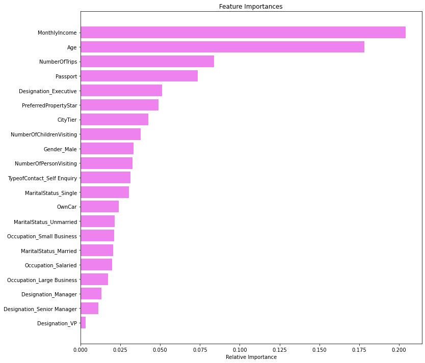

```python
importances = rf_estimator.feature_importances_
indices = np.argsort(importances)

plt.figure(figsize=(12,12))
plt.title('Feature Importances')
plt.barh(range(len(indices)), importances[indices], color='violet', align='center')
plt.yticks(range(len(indices)), [feature_names[i] for i in indices])
plt.xlabel('Relative Importance')
plt.show()
```

```python
# defining a function to compute different metrics to check performance of a classification model built using sklearn
def model_performance_classification_sklearn(model, predictors, target):
    """
    Function to compute different metrics to check classification model performance

    model: classifier
    predictors: independent variables
    target: dependent variable
    """

    # predicting using the independent variables
    pred = model.predict(predictors)

    acc = accuracy_score(target, pred)  # to compute Accuracy
    recall = recall_score(target, pred)  # to compute Recall
    precision = precision_score(target, pred)  # to compute Precision
    f1 = f1_score(target, pred)  # to compute F1-score

    # creating a dataframe of metrics
    df_perf = pd.DataFrame(
        {
            "Accuracy": acc,
            "Recall": recall,
            "Precision": precision,
            "F1": f1,
        },
        index=[0],
    )

    return df_perf
```

```python
def confusion_matrix_sklearn(model, predictors, target):
    """
    To plot the confusion_matrix with percentages

    model: classifier
    predictors: independent variables
    target: dependent variable
    """
    y_pred = model.predict(predictors)
    cm = confusion_matrix(target, y_pred)
    labels = np.asarray(
        [
            ["{0:0.0f}".format(item) + "\n{0:.2%}".format(item / cm.flatten().sum())]
            for item in cm.flatten()
        ]
    ).reshape(2, 2)

    plt.figure(figsize=(6, 4))
    sns.heatmap(cm, annot=labels, fmt="")
    plt.ylabel("True label")
    plt.xlabel("Predicted label")
```

# Boosting

• With boosting we will build four ensemble models.

```
    o   AdaBoost Classifier, Gradient Boosting Classifier, XGBoost Classifier, and a Stacking Classifier.
```

• Models will be built with default parameters initially but will be tuned via hyperparameters to improve performance.

• Metrics calculated will be Accuracy, Precision, Recall, and F1; F1 being most important.

• The F1 score combines Precision and Recall; functions as a balance between the two.

```
    •   Precision works to determine when the costs of False Positive is high.

    •   Recall calculates how many of the Actual Positives our model capture through labeling it as Positive (True Positive)
```

## AdaBoost Classifier

```
   Accuracy    Recall  Precision       F1
0   0.84577  0.300623   0.717472  0.42371
   Accuracy    Recall  Precision        F1
0  0.848526  0.301818   0.741071  0.428941
```

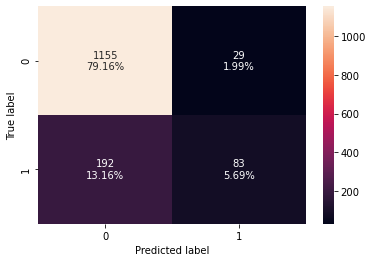

```python
#Fitting the model
ab_classifier = AdaBoostClassifier(random_state=1)
ab_classifier.fit(X_train,y_train)

#Calculating different metrics
ab_classifier_model_train_perf=model_performance_classification_sklearn(ab_classifier,X_train,y_train)
print(ab_classifier_model_train_perf)
ab_classifier_model_test_perf=model_performance_classification_sklearn(ab_classifier,X_test,y_test)
print(ab_classifier_model_test_perf)

#Creating confusion matrix
confusion_matrix_sklearn(ab_classifier,X_test,y_test)
```

• This model in generalized, however; the F1 score is too low for this to be deemed a good model. We will tune some Hyperparameters to try for improvement.

# Confustion Matrix

• Customer was predicted to purchase and did: True Positive (observed=1, predicted=1)

• Customer was predicted to purchase and did not: False Positive (observed=0, predicted=1)

• Customer was predicted not to purchase and did not: True Negative (observed=0, predicted=0)

• Customer was predicted not to purchase but did: False Negative (observed=1, predicted=0)

## Adaboost Classifier Tuned

```python
# Choose the type of classifier.
abc_tuned = AdaBoostClassifier(random_state=1)

# Grid of parameters to choose from
parameters = {
    #Let's try different max_depth for base_estimator
    "base_estimator":[DecisionTreeClassifier(max_depth=1),DecisionTreeClassifier(max_depth=2),
                      DecisionTreeClassifier(max_depth=3)],
    "n_estimators": np.arange(10,110,10),
    "learning_rate":np.arange(0.1,2,0.1)
}

# Type of scoring used to compare parameter  combinations
scorer = metrics.make_scorer(metrics.f1_score)

# Run the grid search
grid_obj = GridSearchCV(abc_tuned, parameters, scoring=scorer,cv=5)
grid_obj = grid_obj.fit(X_train, y_train)

# Set the clf to the best combination of parameters
abc_tuned = grid_obj.best_estimator_

# Fit the best algorithm to the data.
abc_tuned.fit(X_train, y_train)
```

```
AdaBoostClassifier(base_estimator=DecisionTreeClassifier(max_depth=3),
                   learning_rate=0.9, n_estimators=100, random_state=1)
```

```
   Accuracy    Recall  Precision        F1
0  0.968273  0.875389   0.952542  0.912338
   Accuracy    Recall  Precision       F1
0  0.874572  0.549091   0.719048  0.62268
```

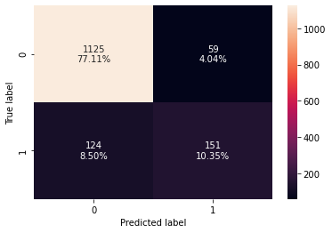

```python
#Calculating different metrics
abc_tuned_model_train_perf=model_performance_classification_sklearn(abc_tuned,X_train,y_train)
print(abc_tuned_model_train_perf)
abc_tuned_model_test_perf=model_performance_classification_sklearn(abc_tuned,X_test,y_test)
print(abc_tuned_model_test_perf)

#Creating confusion matrix
confusion_matrix_sklearn(abc_tuned,X_test,y_test)
```

• The Training Data is a bit overfit Recall, Precision, and F1 have a lot of variation from the Test Data. We will move on to Gradient Boosting.

## Gradient Boosting Classifier

```
Training performance:
    Accuracy    Recall  Precision        F1
0  0.882785  0.468847    0.83844  0.601399
Testing performance:
    Accuracy    Recall  Precision        F1
0  0.861549  0.410909   0.738562  0.528037
```

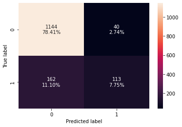

```python
#Fitting the model
gb_classifier = GradientBoostingClassifier(random_state=1)
gb_classifier.fit(X_train,y_train)

#Calculating different metrics
gb_classifier_model_train_perf=model_performance_classification_sklearn(gb_classifier,X_train,y_train)
print("Training performance:\n",gb_classifier_model_train_perf)
gb_classifier_model_test_perf=model_performance_classification_sklearn(gb_classifier,X_test,y_test)
print("Testing performance:\n",gb_classifier_model_test_perf)

#Creating confusion matrix
confusion_matrix_sklearn(gb_classifier,X_test,y_test)
```

• This model is more generalized than the previous (Training Data is overfit). F1 is still too low to settle; we will proceed to tune hyperparameters.

## Gradient Boost Classifier Tuned

```python
# Choose the type of classifier.
gbc_tuned = GradientBoostingClassifier(init=AdaBoostClassifier(random_state=1),random_state=1)

# Grid of parameters to choose from
parameters = {
    "n_estimators": [100,150,200,250],
    "subsample":[0.8,0.9,1],
    "max_features":[0.7,0.8,0.9,1]
}

# Type of scoring used to compare parameter combinations
scorer = metrics.make_scorer(metrics.f1_score)

# Run the grid search
grid_obj = GridSearchCV(gbc_tuned, parameters, scoring=scorer,cv=5)
grid_obj = grid_obj.fit(X_train, y_train)

# Set the clf to the best combination of parameters
gbc_tuned = grid_obj.best_estimator_

# Fit the best algorithm to the data.
gbc_tuned.fit(X_train, y_train)
```

```
GradientBoostingClassifier(init=AdaBoostClassifier(random_state=1),
                           max_features=0.9, n_estimators=250, random_state=1,
                           subsample=1)
```

```
Training performance:
    Accuracy    Recall  Precision        F1
0  0.913925  0.580997   0.939547  0.717998
Testing performance:
    Accuracy    Recall  Precision        F1
0  0.873201  0.458182   0.777778  0.576659
```

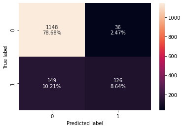

```python
#Calculating different metrics
gbc_tuned_model_train_perf=model_performance_classification_sklearn(gbc_tuned,X_train,y_train)
print("Training performance:\n",gbc_tuned_model_train_perf)
gbc_tuned_model_test_perf=model_performance_classification_sklearn(gbc_tuned,X_test,y_test)
print("Testing performance:\n",gbc_tuned_model_test_perf)

#Creating confusion matrix
confusion_matrix_sklearn(gbc_tuned,X_test,y_test)
```

• We don’t see much improvement in model performance here, despite hyper tuning.

## XGBoost Classifier

```
Training performance:
    Accuracy    Recall  Precision        F1
0  0.995887  0.978193        1.0  0.988976
Testing performance:
    Accuracy    Recall  Precision       F1
0  0.896504  0.596364   0.803922  0.68476
```

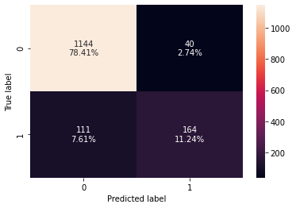

```python
#Fitting the model
xgb_classifier = XGBClassifier(random_state=1, eval_metric='logloss')
xgb_classifier.fit(X_train,y_train)

#Calculating different metrics
xgb_classifier_model_train_perf=model_performance_classification_sklearn(xgb_classifier,X_train,y_train)
print("Training performance:\n",xgb_classifier_model_train_perf)
xgb_classifier_model_test_perf=model_performance_classification_sklearn(xgb_classifier,X_test,y_test)
print("Testing performance:\n",xgb_classifier_model_test_perf)

#Creating confusion matrix
confusion_matrix_sklearn(xgb_classifier,X_test,y_test)
```

• XGBoost has overfit the Training Data. We will try hyperparameter tuning here as well.

## XGBoost Classifier Tuned

```python
# Choose the type of classifier.
xgb_tuned = XGBClassifier(random_state=1, eval_metric='logloss')

# Grid of parameters to choose from
parameters = {
    "n_estimators": [10,30,50],
    "scale_pos_weight":[1,2,5],
    "subsample":[0.7,0.9,1],
    "learning_rate":[0.05, 0.1,0.2],
    "colsample_bytree":[0.7,0.9,1],
    "colsample_bylevel":[0.5,0.7,1]
}

# Type of scoring used to compare parameter combinations
scorer = metrics.make_scorer(metrics.f1_score)

# Run the grid search
grid_obj = GridSearchCV(xgb_tuned, parameters,scoring=scorer,cv=5)
grid_obj = grid_obj.fit(X_train, y_train)

# Set the clf to the best combination of parameters
xgb_tuned = grid_obj.best_estimator_

# Fit the best algorithm to the data.
xgb_tuned.fit(X_train, y_train)
```

```
XGBClassifier(base_score=0.5, booster='gbtree', colsample_bylevel=1,
              colsample_bynode=1, colsample_bytree=0.9, eval_metric='logloss',
              gamma=0, gpu_id=-1, importance_type='gain',
              interaction_constraints='', learning_rate=0.2, max_delta_step=0,
              max_depth=6, min_child_weight=1, missing=nan,
              monotone_constraints='()', n_estimators=50, n_jobs=8,
              num_parallel_tree=1, random_state=1, reg_alpha=0, reg_lambda=1,
              scale_pos_weight=5, subsample=0.9, tree_method='exact',
              validate_parameters=1, verbosity=None)
```

```
Training performance:
    Accuracy    Recall  Precision        F1
0  0.958578  0.985981   0.827451  0.899787
Testing performance:
    Accuracy    Recall  Precision        F1
0   0.85401  0.752727   0.588068  0.660287
```

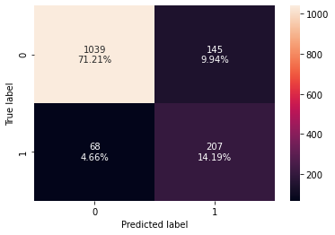

```python
#Calculating different metrics
xgb_tuned_model_train_perf=model_performance_classification_sklearn(xgb_tuned,X_train,y_train)
print("Training performance:\n",xgb_tuned_model_train_perf)
xgb_tuned_model_test_perf=model_performance_classification_sklearn(xgb_tuned,X_test,y_test)
print("Testing performance:\n",xgb_tuned_model_test_perf)

#Creating confusion matrix
confusion_matrix_sklearn(xgb_tuned,X_test,y_test)
```

• The overfitting persists, continuing on to Stacking.

## Stacking Classifier

```python
estimators = [('Random Forest',rf_estimator), ('Gradient Boosting',gbc_tuned), ('Decision Tree',dtree_estimator)]

final_estimator = xgb_tuned

stacking_classifier= StackingClassifier(estimators=estimators,final_estimator=final_estimator)

stacking_classifier.fit(X_train,y_train)
```

```
StackingClassifier(estimators=[('Random Forest',
                                RandomForestClassifier(max_features=0.7,
                                                       n_estimators=251,
                                                       random_state=1)),
                               ('Gradient Boosting',
                                GradientBoostingClassifier(init=AdaBoostClassifier(random_state=1),
                                                           max_features=0.9,
                                                           n_estimators=250,
                                                           random_state=1,
                                                           subsample=1)),
                               ('Decision Tree',
                                DecisionTreeClassifier(class_weight={0: 0.17,
                                                                     1: 0.83},
                                                       max_depth=2...
                                                 eval_metric='logloss', gamma=0,
                                                 gpu_id=-1,
                                                 importance_type='gain',
                                                 interaction_constraints='',
                                                 learning_rate=0.2,
                                                 max_delta_step=0, max_depth=6,
                                                 min_child_weight=1,
                                                 missing=nan,
                                                 monotone_constraints='()',
                                                 n_estimators=50, n_jobs=8,
                                                 num_parallel_tree=1,
                                                 random_state=1, reg_alpha=0,
                                                 reg_lambda=1,
                                                 scale_pos_weight=5,
                                                 subsample=0.9,
                                                 tree_method='exact',
                                                 validate_parameters=1,
                                                 verbosity=None))
```

```
Training performance:
    Accuracy  Recall  Precision        F1
0  0.987074     1.0    0.93586  0.966867
Testing performance:
    Accuracy    Recall  Precision        F1
0  0.878684  0.887273   0.625641  0.733835
```

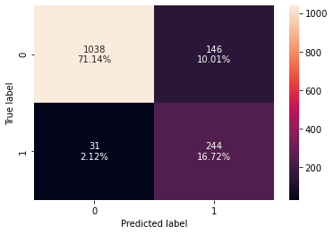

```python
#Calculating different metrics
stacking_classifier_model_train_perf=model_performance_classification_sklearn(stacking_classifier,X_train,y_train)
print("Training performance:\n",stacking_classifier_model_train_perf)
stacking_classifier_model_test_perf=model_performance_classification_sklearn(stacking_classifier,X_test,y_test)
print("Testing performance:\n",stacking_classifier_model_test_perf)

#Creating confusion matrix
confusion_matrix_sklearn(stacking_classifier,X_test,y_test)
```

• The Stacking Classifier slightly reduced overfitting

• This model does well at predicting customers that will not make a purchase but has some opportunities on predicting the one’s that will.

# Comparing All Models

```python
# training performance comparison

models_train_comp_df = pd.concat(
    [ab_classifier_model_train_perf.T,abc_tuned_model_train_perf.T,gb_classifier_model_train_perf.T,gbc_tuned_model_train_perf.T,xgb_classifier_model_train_perf.T,
    xgb_tuned_model_train_perf.T,stacking_classifier_model_train_perf.T],
    axis=1,
)
models_train_comp_df.columns = [
    "Adaboost Classifier",
    "Adabosst Classifier Tuned",
    "Gradient Boost Classifier",
    "Gradient Boost Classifier Tuned",
    "XGBoost Classifier",
    "XGBoost Classifier Tuned",
    "Stacking Classifier"]
print("Training performance comparison:")
models_train_comp_df
```

```
Training performance comparison:
```

|  | Adaboost Classifier | Adabosst Classifier Tuned | Gradient Boost Classifier | Gradient Boost Classifier Tuned | XGBoost Classifier | XGBoost Classifier Tuned | Stacking Classifier |
| --- | --- | --- | --- | --- | --- | --- | --- |
| Accuracy | 0.845770 | 0.968273 | 0.882785 | 0.913925 | 0.995887 | 0.958578 | 0.987074 |
| Recall | 0.300623 | 0.875389 | 0.468847 | 0.580997 | 0.978193 | 0.985981 | 1.000000 |
| Precision | 0.717472 | 0.952542 | 0.838440 | 0.939547 | 1.000000 | 0.827451 | 0.935860 |
| F1 | 0.423710 | 0.912338 | 0.601399 | 0.717998 | 0.988976 | 0.899787 | 0.966867 |

```python
# training performance comparison

models_test_comp_df = pd.concat(
    [ab_classifier_model_test_perf.T,abc_tuned_model_test_perf.T,gb_classifier_model_test_perf.T,gbc_tuned_model_test_perf.T,xgb_classifier_model_test_perf.T,
    xgb_tuned_model_test_perf.T,stacking_classifier_model_test_perf.T],
    axis=1,
)
models_test_comp_df.columns = [
    "Adaboost Classifier",
    "Adabosst Classifier Tuned",
    "Gradient Boost Classifier",
    "Gradient Boost Classifier Tuned",
    "XGBoost Classifier",
    "XGBoost Classifier Tuned",
    "Stacking Classifier"]
print("Testing performance comparison:")
models_test_comp_df
```

```
Testing performance comparison:
```

|  | Adaboost Classifier | Adabosst Classifier Tuned | Gradient Boost Classifier | Gradient Boost Classifier Tuned | XGBoost Classifier | XGBoost Classifier Tuned | Stacking Classifier |
| --- | --- | --- | --- | --- | --- | --- | --- |
| Accuracy | 0.848526 | 0.874572 | 0.861549 | 0.873201 | 0.896504 | 0.854010 | 0.878684 |
| Recall | 0.301818 | 0.549091 | 0.410909 | 0.458182 | 0.596364 | 0.752727 | 0.887273 |
| Precision | 0.741071 | 0.719048 | 0.738562 | 0.777778 | 0.803922 | 0.588068 | 0.625641 |
| F1 | 0.428941 | 0.622680 | 0.528037 | 0.576659 | 0.684760 | 0.660287 | 0.733835 |

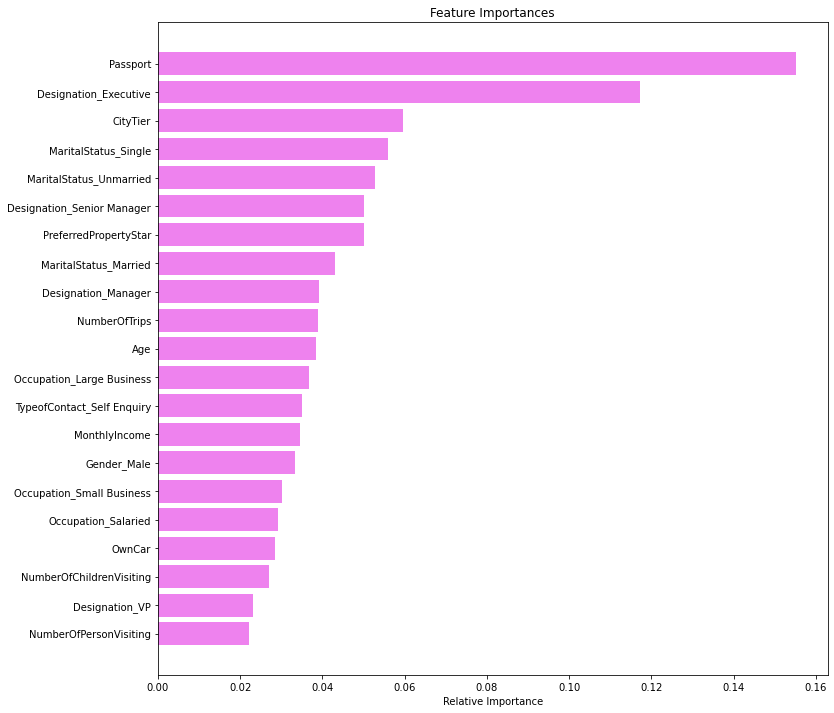

```python
importances = final_estimator.feature_importances_
indices = np.argsort(importances)

plt.figure(figsize=(12,12))
plt.title('Feature Importances')
plt.barh(range(len(indices)), importances[indices], color='violet', align='center')
plt.yticks(range(len(indices)), [feature_names[i] for i in indices])
plt.xlabel('Relative Importance')
plt.show()
```

# Feature importance of Random Forest Estimator: Best Model Recap

• Most of the models over fit and/or didn’t perform well regarding the F1 score.

• The Confusion Matrix does a good job predicting potential customers and non-customers

• Most important variables when rolling out the new package are Monthly Income, Age, and Number of Trips.

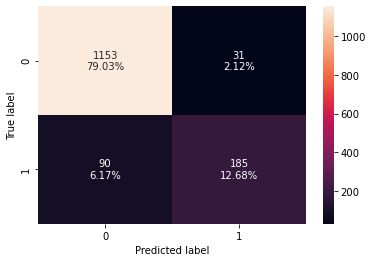

```python
confusion_matrix_sklearn(rf_estimator, X_test,y_test)
```

```python
rf_estimator_model_train_perf=model_performance_classification_sklearn(rf_estimator, X_train,y_train)
print("Training performance \n",rf_estimator_model_train_perf)
```

```
Training performance
    Accuracy  Recall  Precision   F1
0       1.0     1.0        1.0  1.0
```

```python
rf_estimator_model_test_perf=model_performance_classification_sklearn(rf_estimator, X_test, y_test)
print("Testing performance \n",rf_estimator_model_test_perf)
```

```
Testing performance
    Accuracy    Recall  Precision        F1
0  0.917066  0.672727   0.856481  0.753564
```

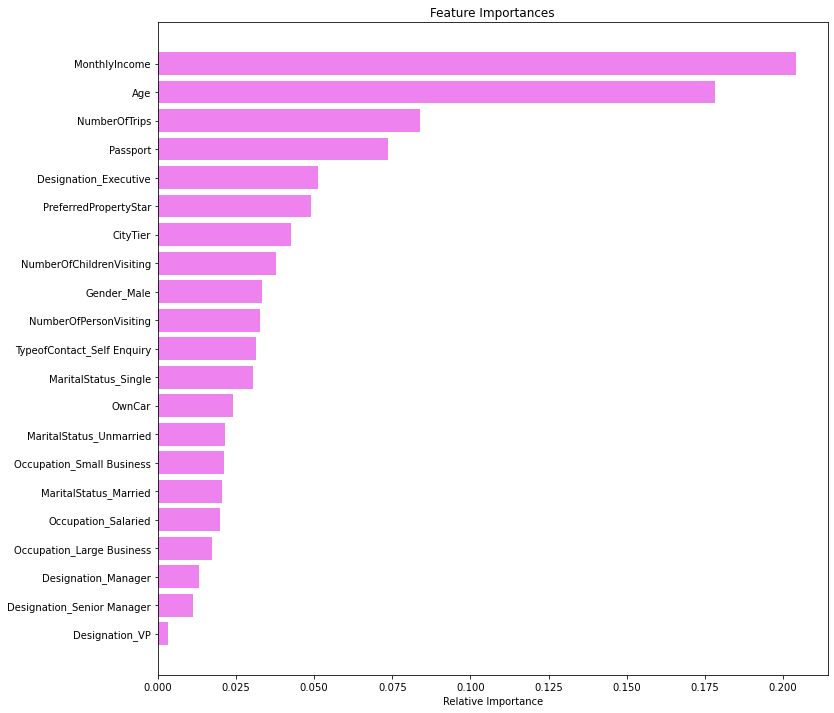

```python
importances = rf_estimator.feature_importances_
indices = np.argsort(importances)

plt.figure(figsize=(12,12))
plt.title('Feature Importances')
plt.barh(range(len(indices)), importances[indices], color='violet', align='center')
plt.yticks(range(len(indices)), [feature_names[i] for i in indices])
plt.xlabel('Relative Importance')
plt.show()
```